# STAT 440: Homework Assignment #4

Due: Thursday, Mar. 6 at 11:59pm on Canvas

Exercise 1(e) calls for writing code. Please use R, and turn in your code along with your written work and any plots you are asked to produce. Just as you strive for clarity in your writing of language, try to write R code that is easy to read, in the sense that a knowledgeable user of R would be able to understand it easily.

You *may* choose to use LaTeX for your mathematics writing in your homework, in which case I recommend R Markdown as an easy way to combine text, mathematics, R code, and R output. But this is not required; you may choose to format your work however you find convenient, as long as you upload your assignment to Canvas as a single pdf document.

## Exercise 1

Example 1 in the Week 07a notes shows that the beta distribution is the conjugate prior when the data are binomially distributed. Here, you’ll instead explore the conjugacy of the gamma distribution when data are Poisson distributed. This is the same relationship we looked at in class while reviewing Question 1 from the FA 2023 midterm exam.

**Part (a)** Suppose that $X_1, \ldots, X_n$ is an i.i.d. sample from a Poisson$(\theta)$ distribution. Define $S_n$ to be the sum of the $X_i$; that is, $S_n = \sum_{i=1}^n X_i$. One of the properties of the Poisson is that $S_n\sim\mbox{Poisson}(n\theta)$. Write down the probability mass function of the data in terms of $S_n$. (This is the likelihood.)

**Part (b)** Suppose that $\theta$ has a gamma prior distribution with shape parameter $\alpha$ and scale parameter $\beta$. (This means that the mean of the prior equals $\alpha\times\beta$.) Write down the prior density function of $\theta$.

**Part (c)** Keeping in mind that the posterior is proportional to the likelihood times the prior, write down the posterior density of $\theta$, up to a multiplicative constant. In other words, you may ignore any multiplicative factors not involving $\theta$ itself. Verify that this density is also a gamma density, and tell what its shape and scale parameters are.

**Part (d)** We often use the posterior mean as a Bayesian point estimate. What is the posterior mean in this situation? Compare it to the typical frequentist estimator of $\theta$, the maximum likelihood estimator, which equals $S_n / n$.

**Part (e)** Suppose the prior on $\theta$ is standard exponential (which is a special case of gamma). Also suppose that from our data, we find $S_n = 3.5$. On the same set of axes, plot the prior density as well as the posterior densities if $n=10$, $n=100$, and $n=1000$. What do you notice?

### Answer

**Part (a)**

$P(X_i =x) = \frac{\theta^xe^{-\theta}}{x!}$ for x = 1, 2, …

$S_n = \sum_{i=1}^nX_i$ and we know that $S_n \sim \mbox {Poisson}(n\theta)$

Find the PMF for $S_n$

By the convolution property of Poisson random variables:

$L(\theta)=P(S_n=x) = \frac{(n\theta)^xe^{-n\theta}}{x!}$

**Part (b)**

$\theta \sim \mbox{Gamma}(\alpha,\beta)$

We are also given that $E[\theta] = \alpha\beta$

The density for theta is: $p(\theta) = \frac{1}{\Gamma(\alpha)\beta^\alpha}\theta^{\alpha-1}e^{-\theta/\beta}$

**Part (c)**

$L(\theta)=\frac{(n\theta)^xe^{-n\theta}}{x!}$

$p(\theta) = \frac{1}{\Gamma(\alpha)\beta^\alpha}\theta^{\alpha-1}e^{-\theta/\beta}$

Then we can get that $p(\theta |S_n) \propto (n\theta)^xe^{-n\theta} * \theta^{\alpha-1}e^{-\theta/\beta}$

If we simplify the equation, we get: $p(\theta |S_n) \propto \theta^{x +\alpha-1}e^{-n\theta -\theta/\beta} = \theta^{x +\alpha-1}e^{-\theta(n + \frac1\beta)}$

This will follow a gamma distribution which has form $p(\theta) \propto \theta^{\alpha-1}e^{-\theta/\beta}$

So the new distribution is $\theta |S_n \sim \mbox{Gamma}(x+\alpha, \frac1{n + 1/\beta})$

**Part (d)**

Since we know the mean of the Gamma distribution, which is just the product of the two parameters.

$E[\theta|S_n]=\frac{x+\alpha}{n + 1/\beta}$

The MLE is equal to $\frac{S_n}n = \frac1n\sum_{i=1}^nX_i$ which means that the MLE of the prior is a sample mean of the observed data. And the expected value of the posterior was found above.

Comparing the two means, we see that the posterior mean is a weighted average depending on the prior.

**Part (e)**

The standard exponential distribution in the form of a Gamma distribution is $\mbox{Gamma}(1,1)$

We are also given that $S_n = 3.5$, we want to plot the prior and the posterior densities for n = 10, 100, 1000

With the information we are given, the posterior is: $\theta|S_n \sim \mbox{Gamma}(4.5, \frac1{n+1})$ because shape is $x + 1 = 3.5 + 1$ and scale is $\frac1{n + 1/\beta} = \frac1{n + 1/1} = \frac1{n+1}$

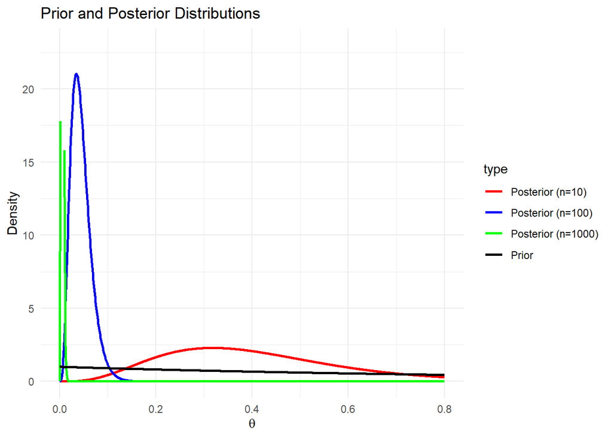

```r
library(ggplot2)

theta <- seq(0, 0.8, length = 1000)

prior_density <- dgamma(theta, shape = 1, scale = 1)

# Define posterior densities for different n values
n_values <- c(10, 100, 1000)
posterior_densities <- lapply(n_values, function(n) {
  dgamma(theta, shape = 4.5, scale = 1 / (n + 1))
})

# Create data frame for ggplot
plot_data <- data.frame(
  theta = rep(theta, times = length(n_values) + 1),
  density = c(prior_density, unlist(posterior_densities)),
  type = factor(rep(c("Prior", paste0("Posterior (n=", n_values, ")")), each = length(theta)))
)

# Plot using ggplot2 with zoomed-in x-axis
ggplot(plot_data, aes(x = theta, y = density, color = type)) +
  geom_line(linewidth = 1) +
  labs(title = "Prior and Posterior Distributions",
       x = expression(theta), y = "Density") +
  scale_color_manual(values = c("red", "blue", "green","black")) +
  theme_minimal() +
  xlim(0, 0.8)+
  ylim(0,23)
```